# EDA

Importing libraries

Loading Data

```r
load('./30103-0001-Data.rda')
df <- da30103.0001
#names(df)
#str(df)
```

Data Cleaning

```r
keeps <- c('RESPONDENT_YRSED',# Approx Respondent yrs education based on ppeduc, first demographic survey
           'PARTNER_YRSED',   #Partner yrs education based on q10
           'PPINCIMP',        #Binned - total combined household income
           'PPWORK',          #employment
           'QFLAG',           # does person have a partner?
           'PAPGLB_STATUS',   #(gay, lesbian, or bisexual)
           'PPMARIT',         # marital status
           'PPGENDER',        # gender
           'Q4',              #( is partner female or male)
           'Q5',              #(is partner same gender)
           'Q23',             # between you and [partner_name], who earned more income in 2008
           'PPETHM',          # race/ethnicity hispanic/latino
           'Q6B',             # race of partner
           'RESPONDENT_RACE',
           'PARTNER_RACE',
           'RELATIONSHIP_QUALITY', # relationship quality, based on q34, higher number is better
           'PPGENDER', #gender
           'PPREG4', #based on state of residence
           'PPREG9', #based on state of residence
           'PPWORK', #current employment status
           'SAME_SEX_COUPLE', #same sex couple
           'PPAGE', #age at the time
           'PAPRELIGION', #religion
           'Q7B', #partner's religion
           'PPQ14ARACE', #race/ethnicity
           'PPEDUC', #Education (highest degree received)
           'PPEDUCAT', #Education categorical
           'PPHOUSE', #Housing type
           'PPRENT', #Ownership status
           'PPMARIT', #marital status
           'PPPARTYID3' #Political Party
          )

# store as new df
df <- df[keeps]

# only keep the partnered people
df <- df[df$QFLAG=='(1) partnered',]
```

### Data Transformation

```r
# add a new column to track difference in education
df['diff_in_education'] = df$RESPONDENT_YRSED - df$PARTNER_YRSED

# add boolean to track difference in race
df['diff_in_race'] = ifelse(df$RESPONDENT_RACE == df$PARTNER_RACE, 0, 1)

# add boolean to track difference in income
df['diff_in_income'] = ifelse(df$Q23 == '(2) we earned about the same amount', 0, 1)

#add Relationship quality
df$relationship_val <- as.numeric(substr(df$RELATIONSHIP_QUALITY, 2, 2))

#add PPWORK
df$work <- as.numeric((substr(df$PPWORK, 2,2)))
#head(df$work)

#PPAGE - numeric
df$PPAGE <- as.numeric(df$PPAGE)

#Convert PPINCIMP to numeric
#df$PPINCIMP <- as.numeric(gsub('[$,]', '', df$PPINCIMP))
```

## Exploratory Data Analysis

1. Relationship Quality – new column relationship_val

```r
glimpse(df$relationship_val)
```

```
##  num [1:3009] 4 4 4 4 4 5 5 5 5 5 ...
```

```r
(summary(df$relationship_val))
```

```
##    Min. 1st Qu.  Median    Mean 3rd Qu.    Max.    NA's
##   1.000   4.000   5.000   4.459   5.000   5.000      13
```

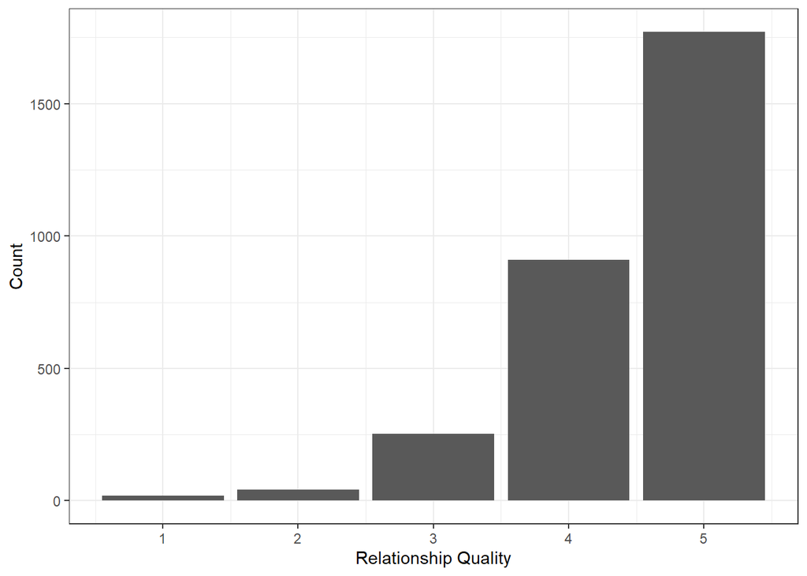

```r
ggplot(df, aes(relationship_val)) + geom_bar() + theme_bw() + xlab("Relationship Quality") + ylab("Count")
```

```r
NA %in% df$RELATIONSHIP_QUALITY
```

```
## [1] TRUE
```

```r
sum(is.na(df$RELATIONSHIP_QUALITY))
```

```
## [1] 13
```

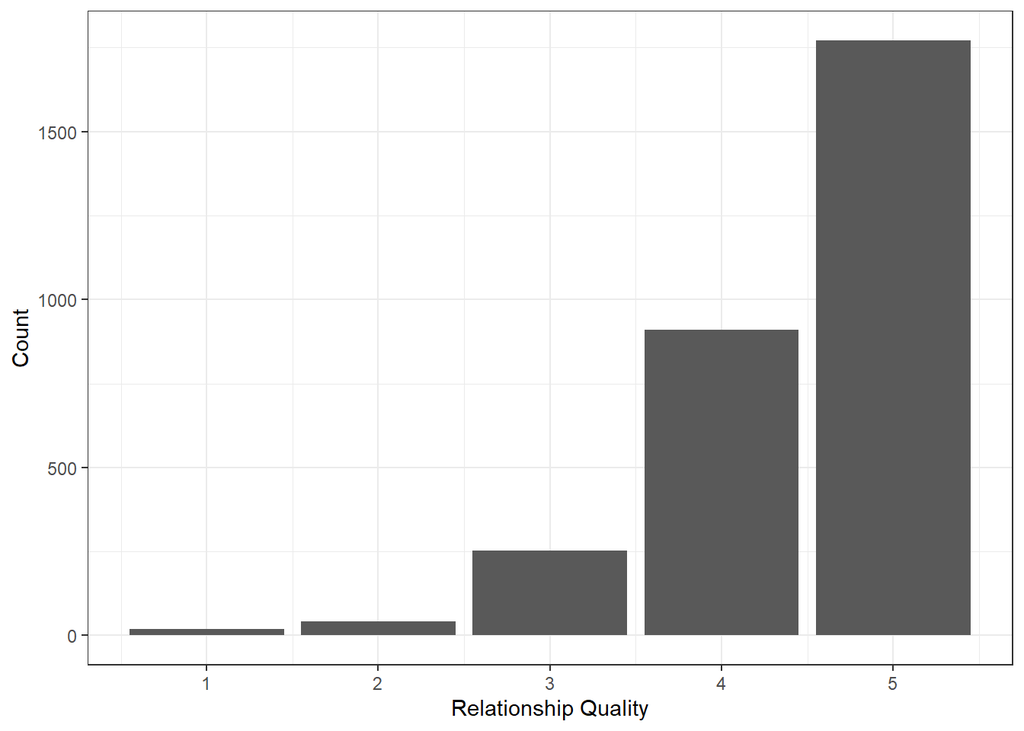

```r
#There's 13 NA values for relationship quality - removing them
df <- df[is.na(df$RELATIONSHIP_QUALITY)==FALSE,]

ggplot(df, aes(relationship_val)) + geom_bar() + theme_bw() + xlab("Relationship Quality") + ylab("Count") + scale_fill_discrete(name = "Title", labels = c("A","B","C","D","E")) + theme(legend.position = "top")
```

Most subject quantify their relationship status as excellent.

2. Current Employment Status

```r
kable(summary(df$PPWORK)) %>% kable_styling(font_size = 14)
```

x

1. working - as a paid employee

1705

2. working - self-employed

271

3. not working - on temporary layoff from a job

15

4. not working - looking for work

113

5. not working - retired

435

6. not working - disabled

224

7. not working - other

233

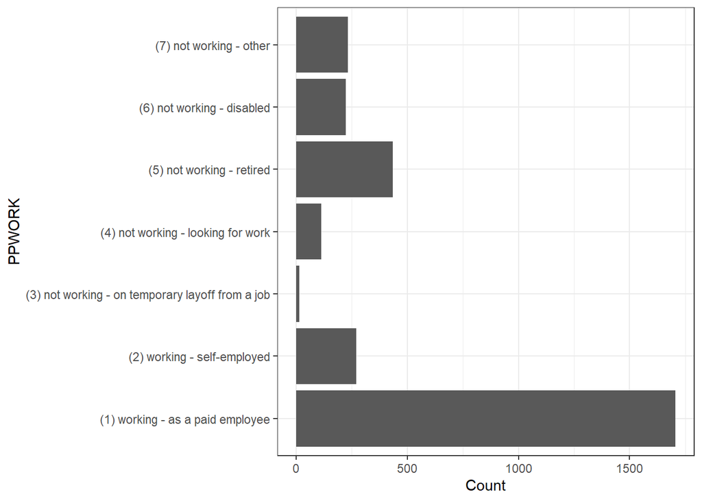

```r
ggplot(df, aes(PPWORK)) + geom_bar() + coord_flip() + theme_bw() + ylab("Count") + theme(legend.position = "bottom")
```

Most of the participants are working as a paid employee.

3. GLB Status

```r
kable(summary(df$PAPGLB_STATUS)) %>% kable_styling(font_size = 14)
```

x

1. yes

670

2. no

2306

3. i would prefer to not answer this question

20

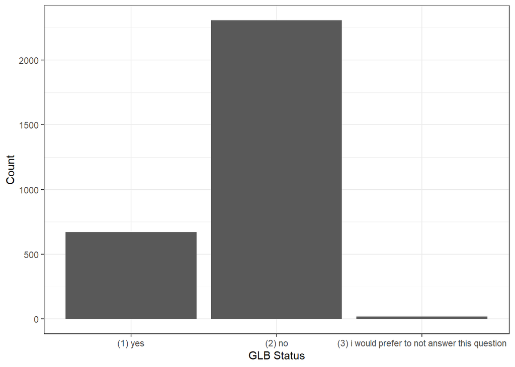

```r
ggplot(df, aes(PAPGLB_STATUS)) + geom_bar() + theme_bw() + xlab("GLB Status") + ylab("Count") + theme(legend.position = "bottom")
```

Approximately, 1/5 of the subjects identify as gay/lesbian/bi.

4. Same Sex couple

```r
kable(summary(df$SAME_SEX_COUPLE)) %>% kable_styling(font_size = 14)
```

x

0. different sex couple

2524

1. same-sex couple

472

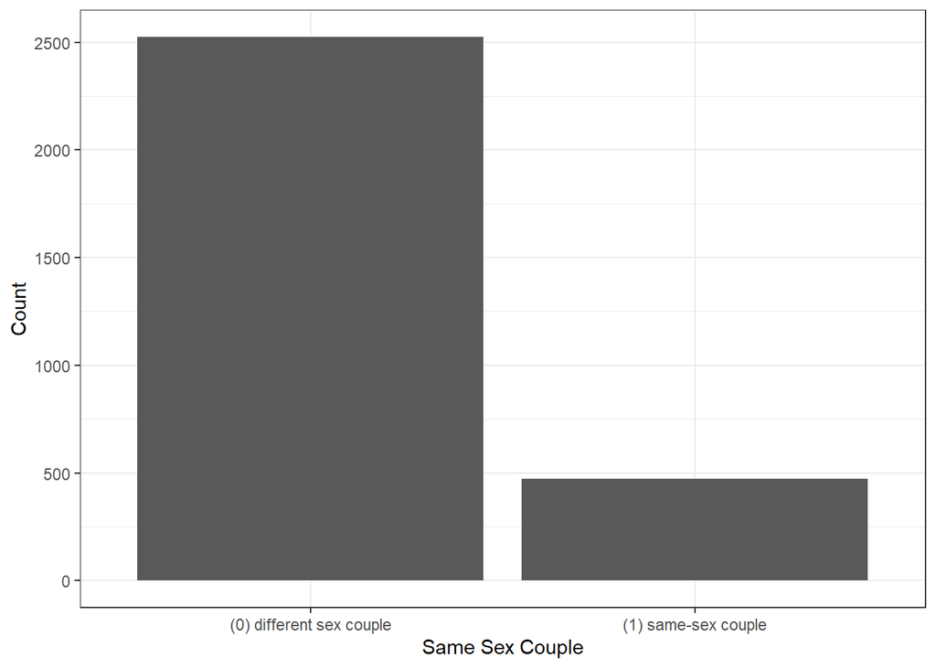

```r
ggplot(df, aes(SAME_SEX_COUPLE)) + geom_bar() + theme_bw() + xlab("Same Sex Couple") + ylab("Count") + theme(legend.position = "bottom")
```

5. Age

```r
summary(df$PPAGE)
```

```
##    Min. 1st Qu.  Median    Mean 3rd Qu.    Max.
##   19.00   34.00   45.00   46.48   57.00   95.00
```

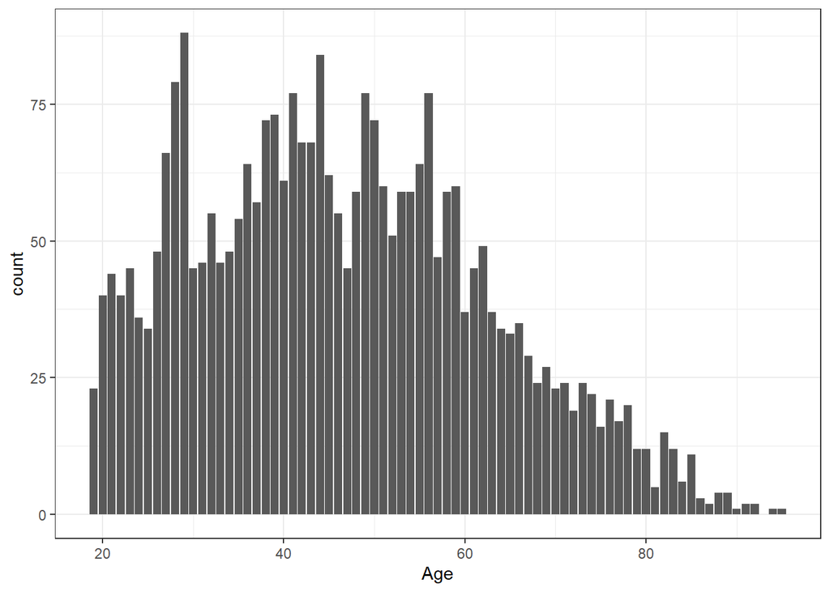

```r
ggplot(df, aes(PPAGE)) + geom_bar() + theme_bw() + xlab("Age")
```

Age ranges from 19 to 95, and is slightly right skewed with a median age of 45.

6. Gender

```r
kable(summary(df$Q4)) %>% kable_styling(font_size = 14)
```

x

1. male

1478

2. female

1512

3. other, please specify

6

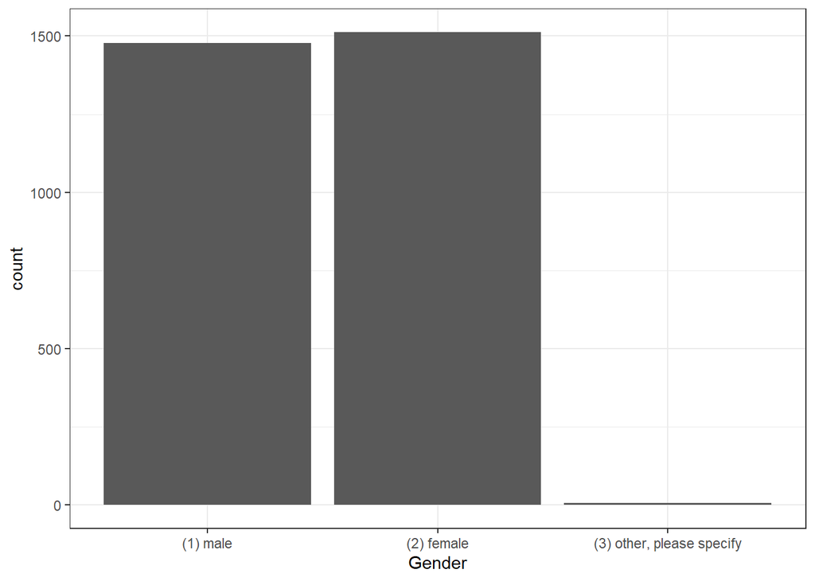

```r
ggplot(df, aes(Q4)) + geom_bar() + theme_bw() + xlab("Gender")
```

Approximately even ratio of males to females.

7. Comparing Religion

```r
kable(summary(df$PAPRELIGION)) %>% kable_styling(font_size = 14)
```

x

1. Baptist- any denomination

395

2. Protestant (e.g., Methodist, Lutheran, Presbyterian, Episcopal)

657

3. Catholic

696

4. Mormon

59

5. Jewish

81

6. Muslim

6

7. Hindu

12

8. Buddhist

23

9. Pentecostal

74

10. Eastern Orthodox

13

11. other Christian

370

12. other non-Christian, please specify

124

13. None

476

NA’s

10

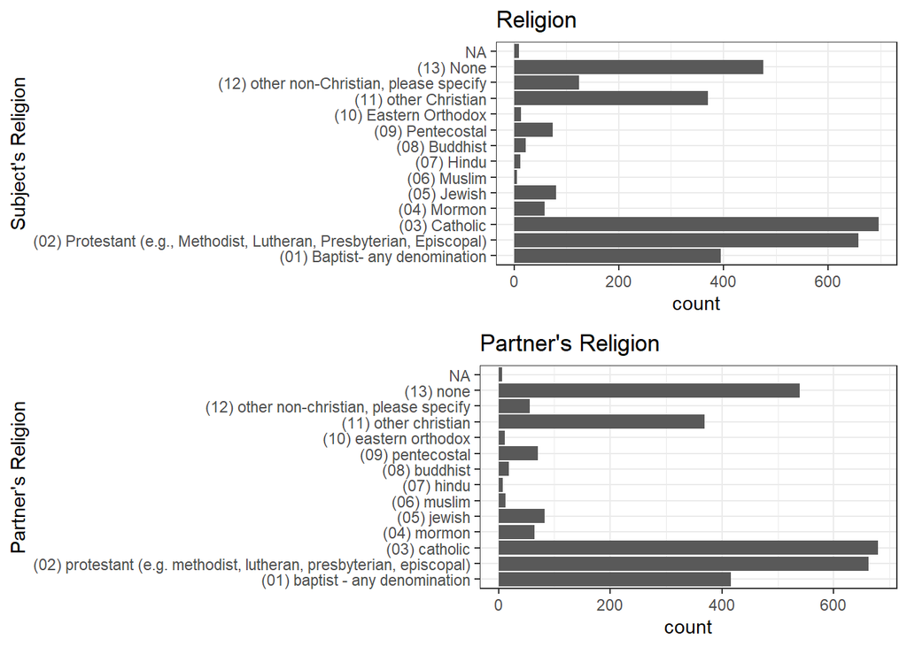

```r
p1 <- ggplot(df, aes(PAPRELIGION)) +
  geom_bar() + theme_bw() +
  coord_flip() + ggtitle("Religion") +
  xlab("Subject's Religion")

p2 <- ggplot(df, aes(Q7B)) +
  geom_bar() + theme_bw() +
  coord_flip() +
  ggtitle("Partner's Religion") +
  xlab("Partner's Religion")

grid.arrange(p1,p2, ncol = 1)
```

8. Race/Ethnicity Distribution

```r
kable(summary(df$PPETHM)) %>% kable_styling()
```

x

1. white, non-hispanic

2252

2. black, non-hispanic

223

3. other, non-hispanic

96

4. hispanic

313

5. 2+ races, non-hispanic

112

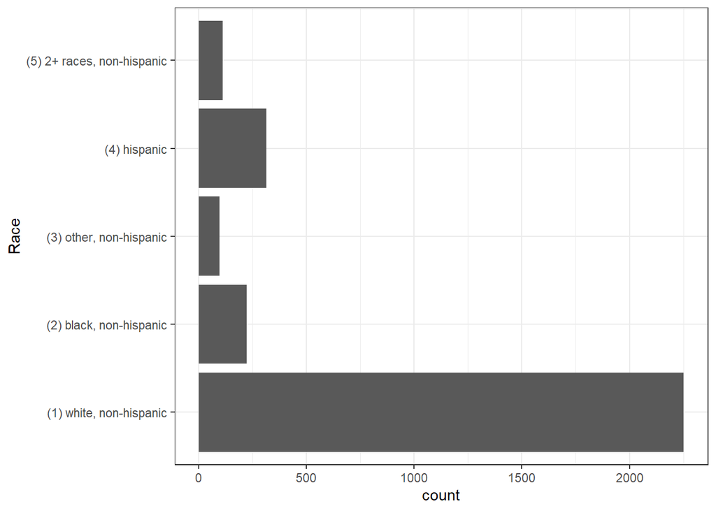

```r
ggplot(df, aes(PPETHM)) + geom_bar() + theme_bw() + xlab("Race") + coord_flip()
```

A large majority of the subjects are white - likely over-represented.

9. Education Distribution

```r
kable(summary(df$PPEDUC)) %>% kable_styling()
```

x

1. no formal education

1

2. 1st, 2nd, 3rd, or 4th grade

2

3. 5th or 6th grade

7

4. 7th or 8th grade

41

5. 9th grade

44

6. 10th grade

59

7. 11th grade

76

8. 12th grade no diploma

91

9. high school graduate - high school diploma or the equivalent (ged)

744

10. some college, no degree

642

11. associate degree

224

12. bachelors degree

655

13. masters degree

285

14. professional or doctorate degree

125

```r
kable(summary(df$PPEDUCAT)) %>% kable_styling()
```

x

1. less than high school

321

2. high school

744

3. some college

866

4. bachelor’s degree or higher

1065

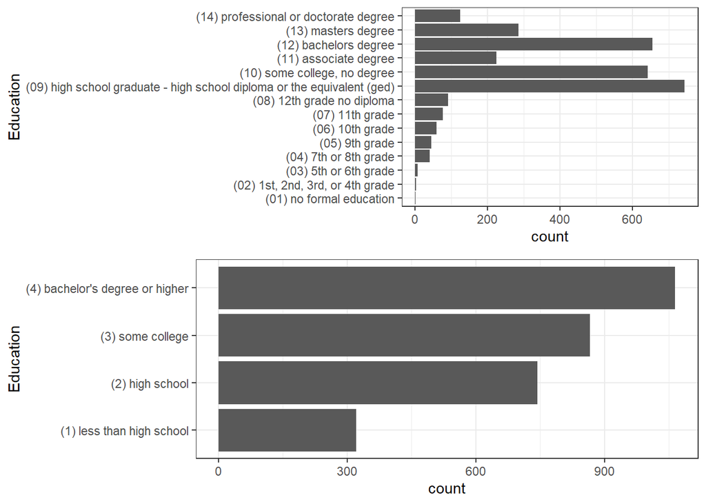

```r
p1 <- ggplot(df, aes(PPEDUC)) + geom_bar() + theme_bw() + xlab("Education") + coord_flip()
p2 <- ggplot(df, aes(PPEDUCAT)) + geom_bar() + theme_bw() + xlab("Education") + coord_flip()

grid.arrange(p1, p2, ncol = 1)
```

10. Household Income Distribution

```r
summary(df$PPINCIMP)
```

```
##     (01) less than $5,000     (02) $5,000 to $7,499     (03) $7,500 to $9,999
##                        20                        30                        42
##   (04) $10,000 to $12,499   (05) $12,500 to $14,999   (06) $15,000 to $19,999
##                        45                        58                        94
##   (07) $20,000 to $24,999   (08) $25,000 to $29,999   (09) $30,000 to $34,999
##                       132                       129                       143
##   (10) $35,000 to $39,999   (11) $40,000 to $49,999   (12) $50,000 to $59,999
##                       189                       296                       348
##   (13) $60,000 to $74,999   (14) $75,000 to $84,999   (15) $85,000 to $99,999
##                       374                       247                       265
## (16) $100,000 to $124,999 (17) $125,000 to $149,999 (18) $150,000 to $174,999
##                       251                       139                        79
##     (19) $175,000 or more
##                       115
```

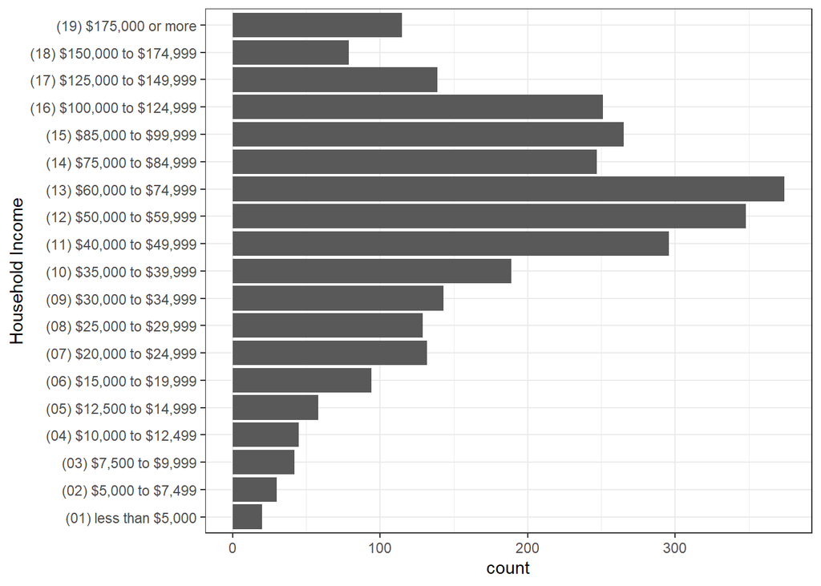

```r
ggplot(df, aes(PPINCIMP)) + geom_bar() + theme_bw() + xlab("Household Income") + coord_flip()
```

The distribution is close to normal with some outliers at the high end.

11. Housing Type

```r
kable(summary(df$PPHOUSE)) %>% kable_styling()
```

x

1. a one-family house detached from any other house

2210

2. a one-family house attached to one or more houses

239

3. a building with 2 or more apartments

424

4. a mobile home

121

5. boat, rv, van, etc.

2

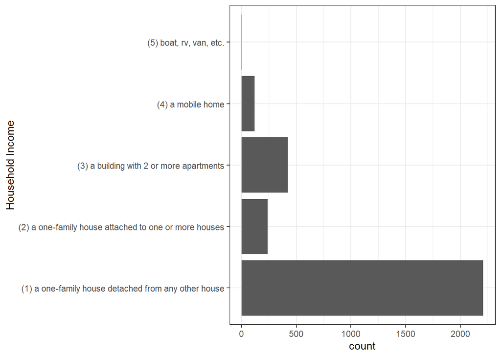

```r
ggplot(df, aes(PPHOUSE)) + geom_bar() + theme_bw() + xlab("Household Income") + coord_flip()
```

Most of the subjects live in a one family house.

12. Rent

```r
kable(summary(df$PPRENT)) %>% kable_styling()
```

x

1. owned or being bought by you or someone in your household

2379

2. rented for cash

585

3. occupied without payment of cash rent

32

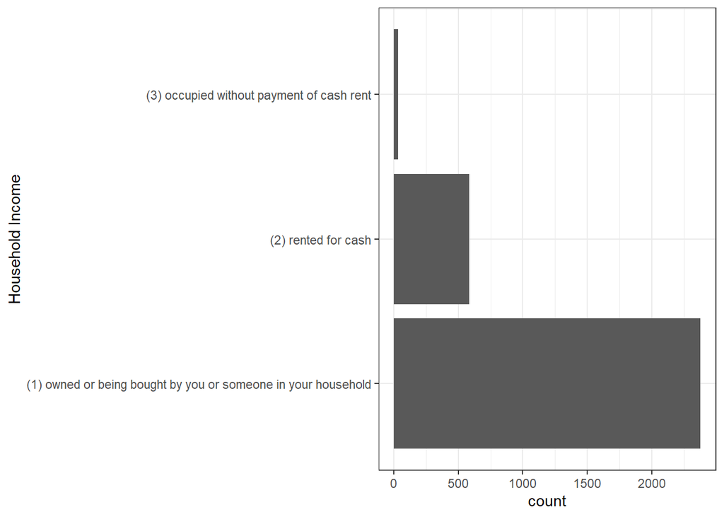

```r
ggplot(df, aes(PPRENT)) + geom_bar() + theme_bw() + xlab("Household Income") + coord_flip()
```

Most of the subjects own the house they live in.

13. Marital Status

```r
kable(summary(df$PPMARIT)) %>% kable_styling()
```

x

1. married

1710

2. widowed

80

3. divorced

212

4. separated

44

5. never married

473

6. living with partner

477

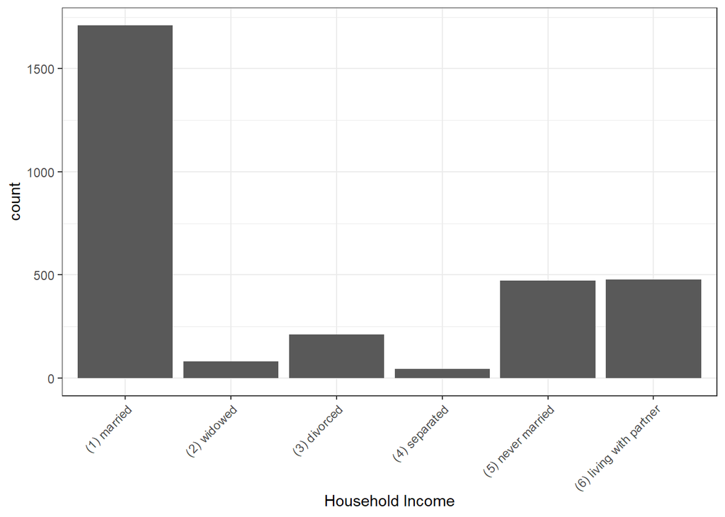

```r
ggplot(df, aes(PPMARIT)) + geom_bar() + theme_bw() + xlab("Household Income") + theme(axis.text.x = element_text(angle = 45, hjust = 1))
```

Most of the subjects are married.

14. Political Party Affiliation

```r
kable(summary(df$PPPARTYID3)) %>% kable_styling()
```

x

1. republican

1184

2. other

72

3. democrat

1740

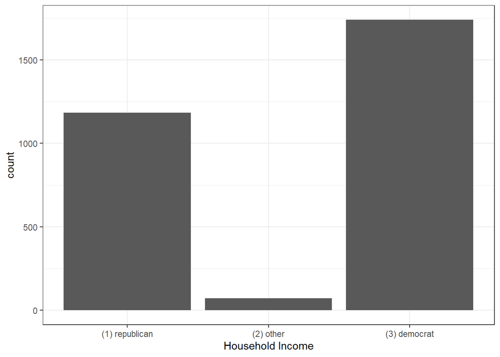

```r
ggplot(df, aes(PPPARTYID3)) + geom_bar() + theme_bw() + xlab("Household Income")
```

Approximately 3:2 ratio of Democrats to Republicans with a small number of independents.

15. Who Earns More?

```r
kable(summary(df$Q23)) %>% kable_styling(font_size = 14)
```

x

1. i earned more

1329

2. we earned about the same amount

374

3. partner earned more

1268

NA’s

25

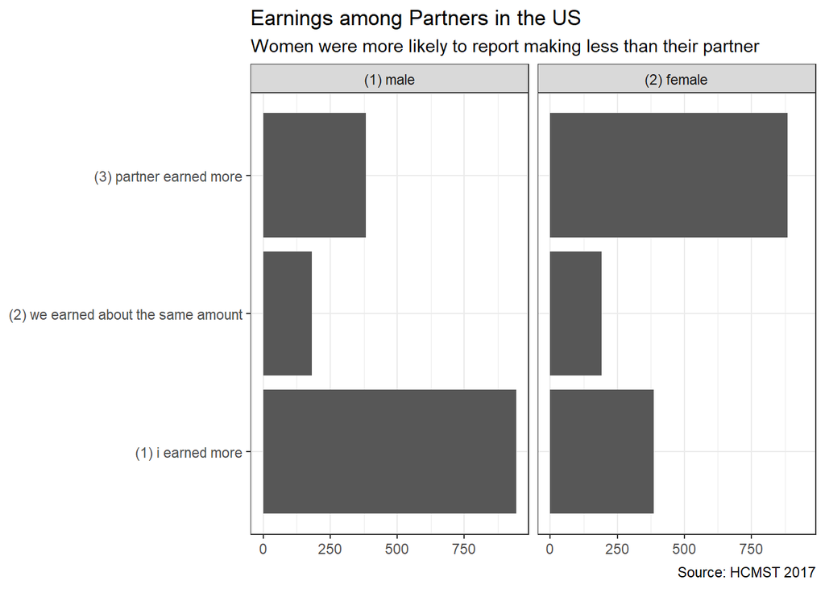

```r
df %>% mutate(Q23 = fct_relevel(Q23,
                           "We earned about the same amount",
                           "partner earned more",
                           "I earned more")) %>%

  mutate(Q23 = fct_recode(Q23,"We earned about the same" = "We earned about the same amount", "My partner earned more" = "[Partner Name] earned more")) %>%

  # Removed those who refused from the dataset as well as those who reported that their partner was not working for pay -- a small total that do not contribute to any major trends

  filter(!is.na(Q23),
         Q23 != "Refused",
         Q23 != "[Partner Name] was not working for pay") %>%  # Create bar chart based on responses for Q23 (respondent's pay versus partner's pay)

  ggplot(aes(x = Q23, fill = PPGENDER)) +

  geom_bar(show.legend=FALSE) +

  facet_wrap(~PPGENDER) +

  coord_flip() +

  theme_bw() +

  scale_fill_manual(values = c("gray34", "gray34")) +

  labs(
    title = "Earnings among Partners in the US",
    subtitle = "Women were more likely to report making less than their partner",
    caption = "Source: HCMST 2017",
    x = NULL, y = NULL)
```